# Analiza danych - raport końcowy

## 1. Wprowadzenie

### 1.1 Mieszkania

Rynek nieruchomości, a w szczególności sektor najmu mieszkań, stanowi jeden z najbardziej dynamicznych elementów współczesnej gospodarki. Wysoki popyt na lokale mieszkalne w dużych aglomeracjach sprawia, że ceny podlegają ciągłym wahaniom, zależnym od szeregu czynników – od lokalizacji i metrażu, po standard wykończenia czy dostępność udogodnień takich jak winda czy parking. Niniejszy raport skupia się na wielowymiarowej analizie danych rynkowych, wykorzystując zaawansowane metody statystyczne do zidentyfikowania kluczowych determinantów ceny oraz stworzenia modelu pozwalającego na rzetelne szacowanie kosztów najmu w oparciu o tysiące rzeczywistych ofert.

### 1.3 Cel analizy

Naszym celem jest nie tylko identyfikacja głównych czynników wpływających na ceny najmu, lecz także wydobycie istotnych trendów rynkowych, które pozwolą nam doskonalić metody prognozowania i wyceny, zapewniając zainteresowanym stronom bardziej precyzyjne i dopasowane rozwiązania.

## 2. Data Wrangling, Cleasing

W ramach przygotowania zbioru do analizy przeprowadzono dwa kluczowe procesy:

- **Data Wrangling** – polega na przekształceniu, reorganizacji i mapowaniu surowych danych do formatu, który jest technicznie gotowy do analizy (np. zmiana typów zmiennych).
- **Data Cleansing** (Czyszczenie danych) – to identyfikacja i eliminacja błędów, niespójności oraz brakujących wartości.

**Cel:** Poprawa jakości danych, co jest fundamentem trafnych decyzji biznesowych.

### 2.1 Komputacja NA

Celem tego etapu jest identyfikacja, wizualizacja oraz uzupełnienie brakujących danych (NA). Braki danych mogą znacząco wpłynąć na jakość modelu predykcyjnego, dlatego kluczowe jest zrozumienie ich struktury – czy występują losowo, czy też wykazują specyficzne wzorce.

#### Mapa braków danych (Overview)

Na początek wykorzystujemy funkcję `vis_miss` z pakietu `naniar`, aby uzyskać ogólny podgląd kompletności zbioru. Wykres przedstawia “mapę” całego arkusza danych, gdzie czarne paski oznaczają brakujące wartości. Pozwala to na szybką ocenę, które zmienne są najbardziej problematyczne.

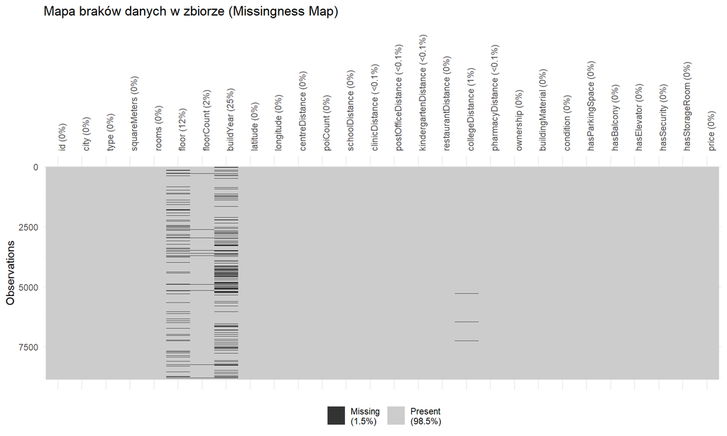

**Interpretacja Mapy Braków Danych**

Wykres przedstawia rozkład brakujących wartości w zbiorze danych liczącym ok. 8000 obserwacji. Ogólny stan kompletności danych jest bardzo wysoki, ponieważ braki stanowią jedynie 1,5% całego zbioru.

#### Analiza wzorców (Pattern Analysis)

Aby dokładniej zrozumieć strukturę braków, stosujemy funkcję md.pattern. Wykres ten (w kolorach niebieskim i różowym) pokazuje kombinacje braków.

Kolor niebieski: Dane dostępne.

Kolor różowy: Brak danych. Wizualizacja ta pomaga odpowiedzieć na pytanie: “Czy jeśli brakuje nam informacji o roku budowy, to zazwyczaj brakuje też informacji o piętrze?”.

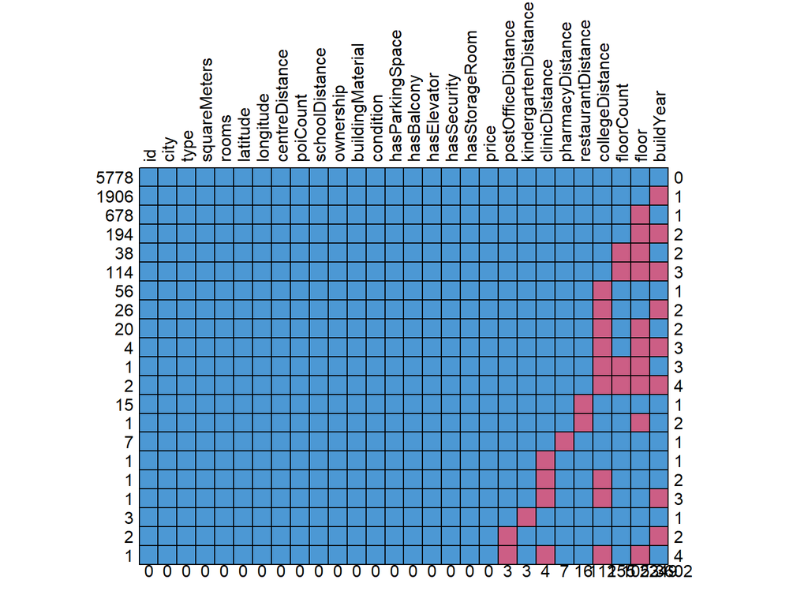

**Interpretacja md.pattern**

Zbiór danych wykazuje znaczące braki w informacjach o roku budowy (25%) oraz piętrze (12%). Uzupełnieniem powyższej analizy jest wykres gg_miss_upset (tzw. Upset Plot). Pionowe słupki pokazują liczebność poszczególnych kombinacji brakujących zmiennych. Pozwala to szybko zidentyfikować najczęstsze “scenariusze” braków danych.

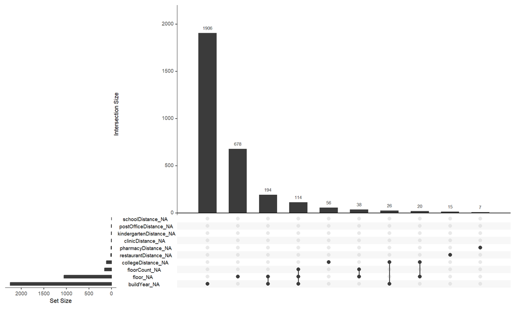

**Interpretacja Upset Plot**

Wykres wskazuje, że zdecydowanie najczęstszym scenariuszem braków jest brak wyłącznie roku budowy, co dotyczy aż 1906 rekordów. Kolejnym istotnym wzorcem jest brak samej informacji o piętrze (678 przypadków), podczas gdy współwystępowanie obu tych braków jednocześnie zdarza się znacznie rzadziej, bo w 194 ogłoszeniach. Pozostałe kombinacje brakujących danych, w tym odległości do punktów użyteczności publicznej (POI), mają charakter marginalny i występują incydentalnie.

#### Zależność braków od zmiennych kategorycznych

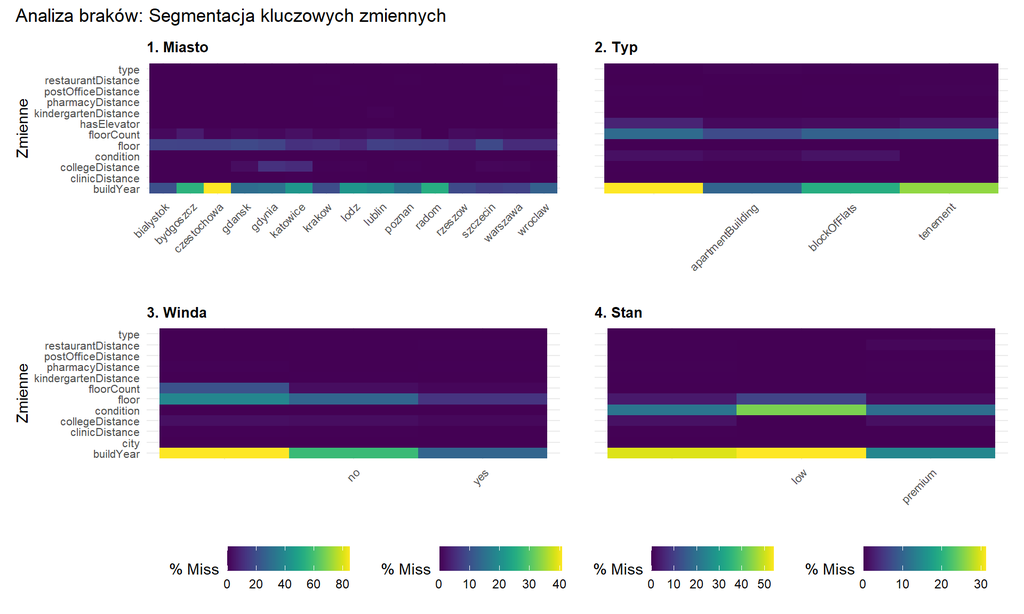

**Interpretacja mapy ciepła braków danych**

### 2.2 Struktura danych

W tym kroku przyglądamy się technicznej stronie zbioru danych. Sprawdzamy typy zmiennych (czy liczby są liczbami, a tekst tekstem), rozkład wartości oraz różnorodność kategorii. Pozwala to wyłapać anomalie, takie jak np. literówki w nazwach miast czy nierealistyczne ceny.

##### Wizualizacja typów danych (Data Types)

Poniższy wykres (`vis_dat`) to “zdjęcie rentgenowskie” naszego zbioru danych. Każda kolumna to zmienna, a kolory oznaczają typ danych (np. liczby całkowite, napisy). * Pozwala szybko ocenić, czy R poprawnie zinterpretował dane (np. czy cena nie jest traktowana jako tekst). * Szare pola (jeśli są) wskazują miejsca brakujące (NA).

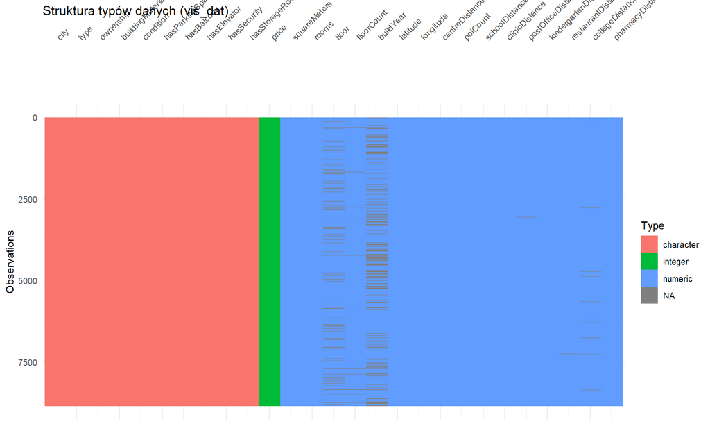

**Interpretacja wizualizacji typów danych**

Wykres vis_dat potwierdza poprawną interpretację typów danych w zbiorze, w którym dominują zmienne numeryczne (kolor niebieski) oraz tekstowe (kolor czerwony). Szare obszary w kolumnach buildYear oraz floor wyraźnie obrazują lokalizację braków danych, co jest w pełni spójne z wynikami uzyskanymi na poprzednich etapach analizy. Taki „rentgen” zbioru pozwala na szybką walidację formatu wszystkich parametrów dla blisko 8000 rekordów przed rozpoczęciem procesów statystycznych.

##### Analiza unikalnych wartości

Poniższa tabela pokazuje, ile unikalnych wartości ma każda zmienna.

Zmienne o małej liczbie unikalnych wartości (np. 2-5) to zazwyczaj zmienne kategoryczne (np. hasElevator, condition).

Zmienne o dużej liczbie wartości to zmienne ciągłe (np. price, latitude).

Liczba unikalnych wartości w kolumnach

| Zmienna | Liczba_Unikalnych |
| --- | --- |
| ownership | 1 |
| hasParkingSpace | 2 |
| hasBalcony | 2 |
| hasSecurity | 2 |
| hasStorageRoom | 2 |
| buildingMaterial | 3 |
| condition | 3 |
| hasElevator | 3 |
| type | 4 |
| rooms | 6 |
| city | 15 |
| floor | 21 |
| floorCount | 29 |
| buildYear | 135 |
| poiCount | 165 |
| price | 515 |
| restaurantDistance | 994 |
| kindergartenDistance | 1010 |
| pharmacyDistance | 1021 |
| centreDistance | 1119 |
| schoolDistance | 1164 |
| postOfficeDistance | 1332 |
| squareMeters | 1505 |
| clinicDistance | 2089 |
| collegeDistance | 2854 |
| latitude | 7004 |
| longitude | 7078 |

##### Proporcje dla kluczowych kategorii

Poniżej sprawdzamy rozkład (liczność) dla najważniejszych zmiennych opisowych. Pozwala to ocenić, czy mamy do czynienia z niezbalansowanymi danymi (np. czy 99% mieszkań jest w stanie “Premium”).

##### Materiał budowy (buildingMaterial):

```
##
##                     brick concreteSlab
##         3505         4920          424
```

##### Stan mieszkania (condition):

```
##
##             low premium
##    6329      32    2488
```

##### Dostępność windy (hasElevator):

```
##
##        no  yes
##  496 2717 5636
```

### 2.4 Data Cleansing (Transformacja zmiennych)

Na tym etapie przygotowujemy dane do modelowania. Większość algorytmów uczenia maszynowego nie potrafi przetwarzać surowego tekstu (np. “winda: tak”, “materiał: cegła”). Konieczna jest konwersja zmiennych kategorycznych (jakościowych) na format numeryczny.

Poniższe wykresy obrazują ten proces transformacji.

#### Wizualizacja przed i po transformacji

Pierwszy wykres pokazuje surowy zbiór danych. Kolor **czerwony/różowy** oznacza zmienne tekstowe (`character`), które są niezrozumiałe dla modelu matematycznego. Drugi wykres pokazuje ten sam zbiór po zastosowaniu funkcji czyszczącej. Wszystkie zmienne zostały przekonwertowane na **typy numeryczne (zielony/niebieski)**, co oznacza pełną gotowość do analizy.

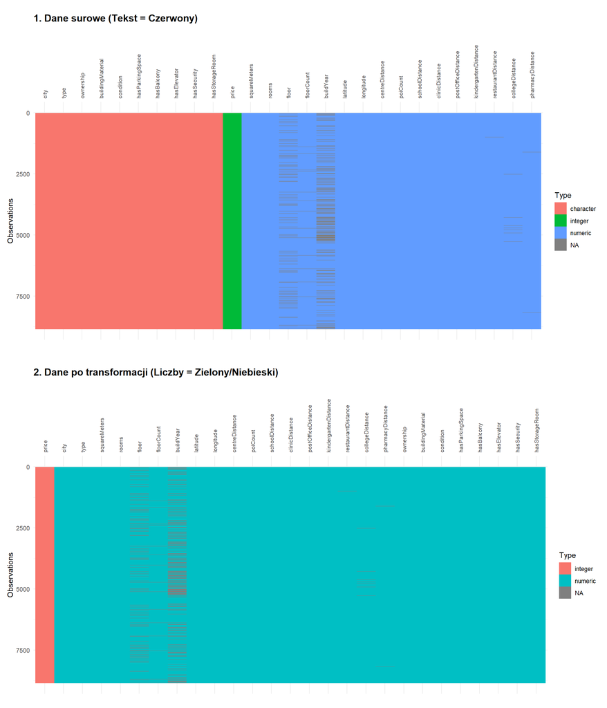

### 2.5 Segmentacja ofert (Klastrowanie)

W celu głębszego zrozumienia rynku, zamiast analizować każde mieszkanie z osobna, pogrupujemy je w podobne do siebie segmenty. Wykorzystamy algorytm **K-Means**.

#### Wybór optymalnej liczby grup

Metoda “Silhouette” wskazała, że najbardziej optymalnym podziałem zbioru jest podział na **2 klastry** (najwyższa wartość na wykresie). Oznacza to, że rynek dzieli się naturalnie na dwie wyraźne kategorie ofert.

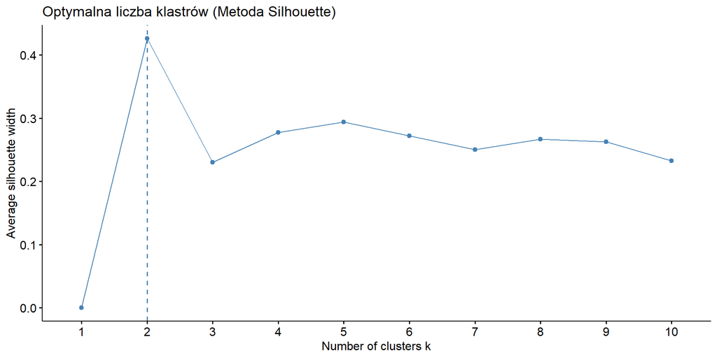

#### Wizualizacja segmentów (Cluster Plot)

Dokonujemy podziału rynku na 2 główne segmenty. Poniższy wykres pokazuje, jak te dwie grupy są odseparowane od siebie w przestrzeni cech.

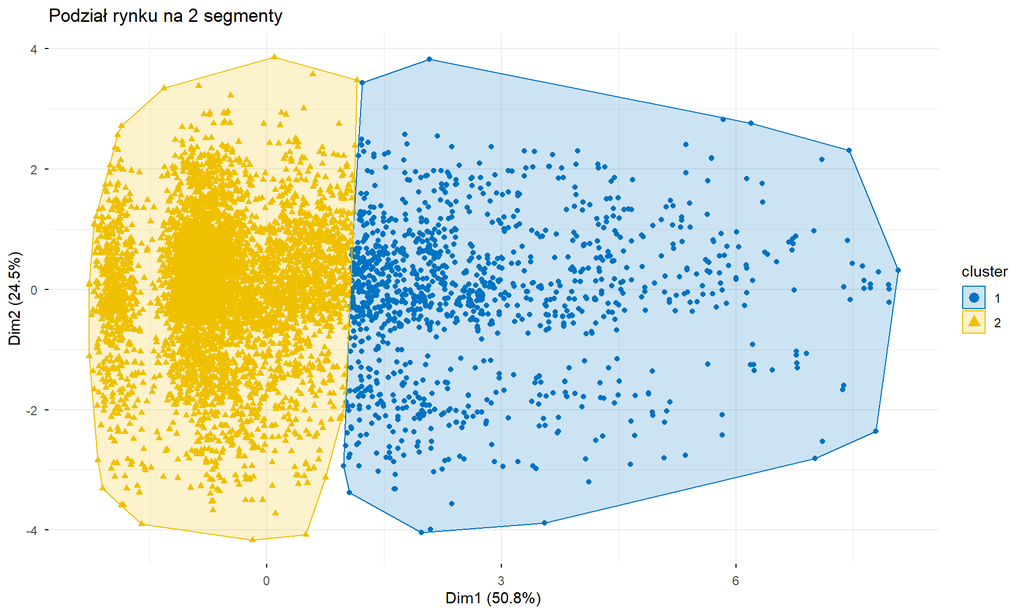

#### Charakterystyka grup (Profilowanie)

Aby zrozumieć, czym różnią się te dwie grupy ( “Mieszkanie tanie” vs “drogie”), spójrzmy na średnie wartości.

Porównanie parametrów dla 2 segmentów

| Cluster | Liczba_Ofert | Cena_Srednia | Metraz_Sredni | Pokoje_Srednie | Odleglosc_Centrum | Rok_Budowy |
| --- | --- | --- | --- | --- | --- | --- |
| 1 | 1205 | 7525 | 93.2 | 3.7 | 3.66 | 1992 |
| 2 | 5395 | 3052 | 46.3 | 2.1 | 4.04 | 2000 |

**Wnioski z segmentacji rynku:**

Algorytm K-Means wyraźnie podzielił rynek na dwie odrębne kategorie, co ma kluczowe znaczenie dla strategii biznesowej i wyceny:

1. **Segment 1: “Premium / Duży Metraż” (Klaster 1)**
   - Stanowi mniejszą część rynku (ok. 18% ofert).
   - Charakteryzuje się **dużą powierzchnią** (średnio 93 m²) i **liczbą pokoi** (blisko 4).
   - Są to nieruchomości znacznie droższe (średnia cena pow. 7500 jednostek walutowych), celujące w klienta zamożnego lub duże rodziny.
   - Co ciekawe, średni rok budowy (1992) jest niższy niż w drugim segmencie, co może sugerować, że do tej grupy trafiają też starsze, przestronne mieszkania w kamienicach lub starsze budownictwo wielorodzinne.
2. **Segment 2: “Standard / Inwestycyjny” (Klaster 2)**
   - Dominuje na rynku (ponad 80% ofert).
   - To typowe mieszkania dwupokojowe o powierzchni ok. 46 m².
   - Średnia cena (ok. 3000) jest ponad dwukrotnie niższa niż w segmencie premium.
   - Są to mieszkania nowsze (średni rok 2000), co idealnie wpisuje się w profil popularnych mieszkań deweloperskich lub lokali pod wynajem (“kawalerki” i “dwójki”).

## 3. Wizualizacja danych

### 3.1 Wykresy pudełkowe

Wykresy pudełkowe wykorzstane zostały do graficznego przedstawienia analizy kluczowych czynników wpływających na zróżnicowanie stawek na rynku nieruchomości. Poprzez zestawienie danych w formie czytelnych wykresów, zidentyfikowane zostały zależności między ceną a standardem, lokalizacją oraz parametrami technicznymi lokali. Uzyskamy dzięki nim lepsze zrozumienie struktury rynku i wskazanie segmentów generujących najwyższe koszty najmu.

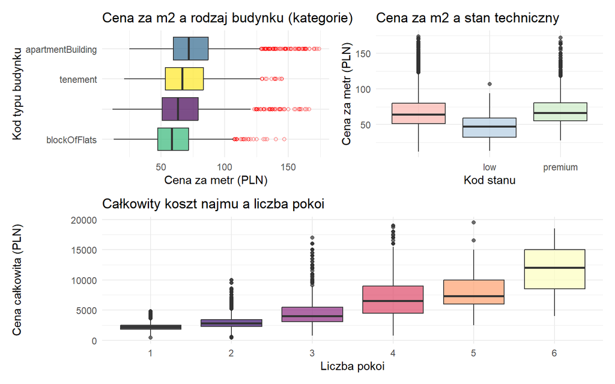

### 3.2 Wykresy słupkowe

Wykresy słupkowe posłużyły do graficznej analizy ilościowej strukturze ofert oraz zestawieniu średnich wartości cenowych w kluczowych kategoriach. Umożliwi to precyzyjne wskazanie, typów nieruchomości dominujących w bazie danych oraz jak rozkładu kosztów najmu w zależności od wielkości mieszkania.

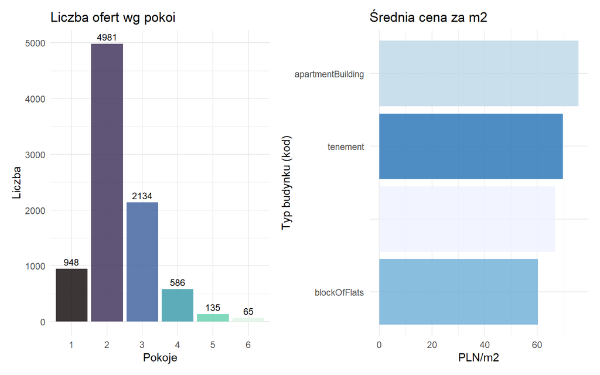

**Interpretacja wykresów**

Analiza struktury ogłoszeń wykazuje wyraźną dominację mieszkań dwu- i trzypokojowych, co sugeruje, że rynek jest zorientowany głównie na segment popularny i potrzeby rodzin. Zestawienie średnich cen potwierdza, że typ zabudowy jest silnym predyktorem kosztów – nowoczesne apartamentowce generują najwyższe stawki za metr kwadratowy, podczas gdy duży wolumen ofert w blokach mieszkalnych utrzymuje ceny na bardziej stabilnym, niższym poziomie. Wyraźne różnice między kategoriami wskazują, że standard budynku jest dla najemców kluczowym czynnikiem przy akceptacji wyższych stawek czynszu.

## 4. Analiza opisowa

### 4.1 Statystyki opisowe

Statystyki opisowe stanowią fundament analizy, pozwalając na liczbowe podsumowanie tendencji centralnej oraz rozproszenia kluczowych cech rynkowych. Dzięki nim możliwe jest precyzyjne określenie profilu typowej oferty oraz zidentyfikowanie skali zróżnicowania cenowego w badanym zbiorze danych.

Tabela: Podsumowanie statystyczne kluczowych parametrów

| Zmienna | Min | Mediana | Średnia | Max | Odch. std. |
| --- | --- | --- | --- | --- | --- |
| centreDistance | 0.02 | 3.29 | 3.81 | 16.61 | 2.62 |
| price | 415.00 | 3000.00 | 3704.23 | 19500.00 | 2318.65 |
| rooms | 1.00 | 2.00 | 2.34 | 6.00 | 0.87 |
| squareMeters | 25.00 | 48.60 | 54.10 | 150.00 | 22.51 |

**Interpretacja statystyk opisowych**

Zestawienie liczbowe ujawnia istotne zróżnicowanie stawek najmu, gdzie wyraźna różnica między średnią a medianą cen sygnalizuje obecność ofert luksusowych zawyżających ogólny wynik. Wysokie odchylenie standardowe w relacji do ceny sugeruje, że rynek nie jest jednolity, a na ostateczny koszt silnie wpływają cechy specyficzne lokali. Przeciętny metraż i odległość od centrum wskazują na dominację standardowych mieszkań miejskich, przy czym szeroki zakres od wartości minimalnych do maksymalnych potwierdza dużą rozpiętość standardu dostępnych nieruchomości.

### 4.2 Korelacja

Analiza korelacji pozwala zrozumieć, które cechy nieruchomości mają najsilniejszy związek z jej ceną oraz jak poszczególne parametry wpływają na siebie nawzajem. Wykorzystanie macierzy korelacji ułatwia identyfikację kluczowych czynników cenotwórczych, co jest niezbędne do budowy rzetelnego modelu wyceny.

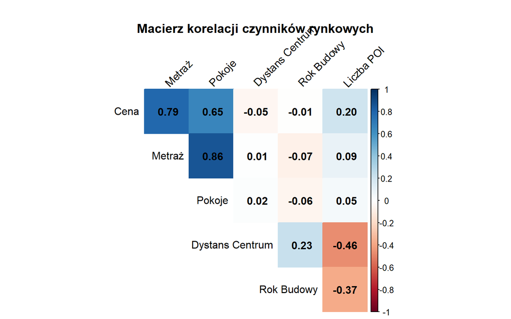

## 5. Wnioskowanie statystyczne

W tej sekcji przejdziemy od opisu danych do weryfikacji hipotez. Sprawdzimy, czy obserwowane na wykresach różnice są istotne statystycznie oraz które parametry mieszkania mają realny wpływ na jego cenę.

### 5.1 Badanie normalności rozkładu

Większość klasycznych testów statystycznych zakłada, że dane mają rozkład normalny. Sprawdzimy to dla zmiennej ceny całkowitej (`price`). Ze względu na dużą liczbę obserwacji, zamiast testu Shapiro-Wilka (który jest bardzo czuły przy dużych próbach), wykorzystamy wizualizację gęstości oraz wykres kwantylowy (Q-Q plot).

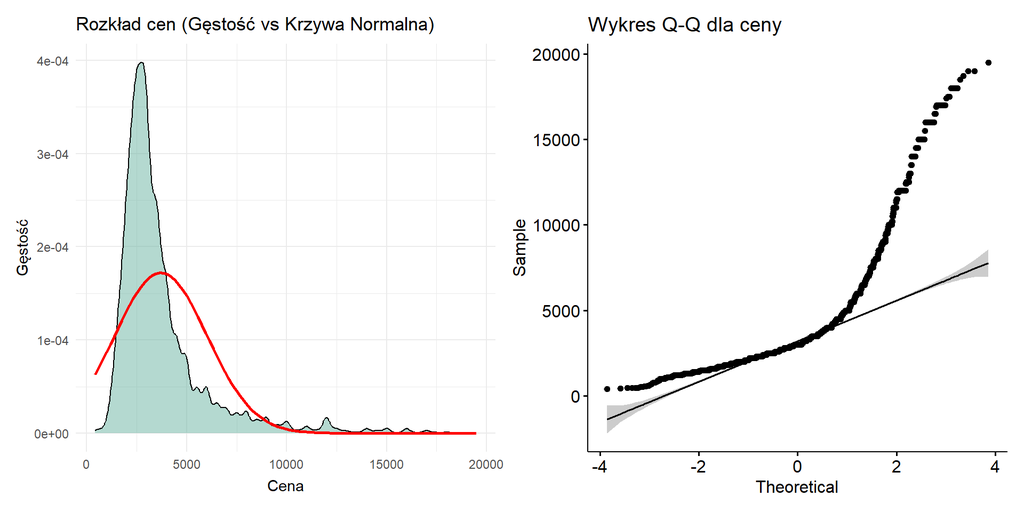

**Interpretacja**

Wykresy wyraźnie pokazują, że rozkład ceny odbiega od normalnego (jest prawostronnie skośny – mamy wiele “tanich” mieszkań i długi ogon ofert luksusowych). W związku z tym w dalszych testach będziemy stosować metody nieparametryczne lub opierać się na dużym rozmiarze próby.

### 5.2 Test istotności różnic (Kruskal-Wallis)

W sekcji 3.1 widzieliśmy różnice w cenach zależnie od rodzaju zabudowy (type). Teraz sprawdzimy, czy te różnice są istotne statystycznie. Użyjemy testu Kruskala-Wallisa (nieparametryczna alternatywa dla ANOVA).

Hipoteza H0: Średnie rangi cen we wszystkich typach budynków są takie same. Hipoteza H1: Przynajmniej jeden typ budynku różni się istotnie ceną od pozostałych.

```
##
##  Kruskal-Wallis rank sum test
##
## data:  price by type
## Kruskal-Wallis chi-squared = 967.5, df = 3, p-value < 2.2e-16
```

**Interpretacja:**

Ponieważ wartość $p-value$ jest ekstremalnie niska (poniżej 0.05), odrzucamy hipotezę zerową. Rodzaj zabudowy ma statystycznie istotny wpływ na cenę najmu.

### 5.3 Modelowanie regresji liniowej

Sprawdzimy, które zmienne najlepiej przewidują cenę. Model regresji pozwoli nam określić siłę wpływu poszczególnych cech (np. metrażu czy odległości od centrum) na końcowy koszt.

Wyniki modelu regresji liniowej

| term | estimate | std.error | statistic | p.value |
| --- | --- | --- | --- | --- |
| (Intercept) | -1831.253 | 1283.156 | -1.427 | 0.154 |
| squareMeters | 89.607 | 1.493 | 60.004 | 0.000 |
| rooms | -252.529 | 39.217 | -6.439 | 0.000 |
| centreDistance | -46.811 | 6.787 | -6.898 | 0.000 |
| buildYear | 0.529 | 0.650 | 0.813 | 0.416 |
| hasElevatorno | 47.691 | 100.321 | 0.475 | 0.635 |
| hasElevatoryes | 706.769 | 99.001 | 7.139 | 0.000 |

## 6. Podsumowanie i wnioski końcowe

Przeprowadzona analiza 8845 ofert mieszkań pozwoliła na kompleksowe zrozumienie struktury polskiego rynku najmu w 2024 roku. Kluczowe wnioski:

Segmentacja rynku: Rynek nie jest jednolity. Wyodrębniliśmy dwa główne segmenty: masowy (inwestycyjny), skupiony na mieszkaniach 40-50 $m^2$, oraz segment premium, obejmujący duże apartamenty, których cena jest kształtowana przez inne czynniki niż w przypadku mieszkań standardowych.